# SETUP:

We are looking for effective marketing agencies to manage our next social media campaign. To decide this, we are provided with a dataset hosted as a BigQuery table.

```python
import warnings
warnings.filterwarnings('ignore')
from google.cloud import bigquery

from scipy.cluster.hierarchy import linkage, dendrogram
from scipy.spatial.distance import squareform
import scipy.stats as stats
import matplotlib.pyplot as plt
import pandas as pd
import numpy as np
import seaborn as sns
import os

plt.style.use("~/.config/matplotlib/custom")
client = bigquery.Client(project='mengus')
```

```python
### PREPARATORY CODE. SKIP TO REACH EXPLORATION

def upload_csv(path, table_id, client=client, job_config=bigquery.LoadJobConfig(
    autodetect=True,  # Infer schema from CSV.
    skip_leading_rows=1,  # Skip header row.
    max_bad_records=10,  # Tolerate up to 10 bad records.
    source_format=bigquery.SourceFormat.CSV,  # Source format is CSV.
)):
    with open(path, "rb") as source_file:
        job = client.load_table_from_file(source_file, table_id, job_config=job_config)
    job.result()  # Wait for job completion.
    destination_table = client.get_table(table_id)
    print("Loaded {} rows.".format(destination_table.num_rows))

def upload_df(df, table_id, client=client, job_config=bigquery.LoadJobConfig(
    autodetect=True,  # Infer schema from DataFrame.
    max_bad_records=10,  # Tolerate up to 10 bad records.
    write_disposition="WRITE_TRUNCATE"  # Overwrite existing table.
)):
    job = client.load_table_from_dataframe(df, table_id, job_config=job_config)
    job.result()  # Wait for job completion.
    destination_table = client.get_table(table_id)
    print("Loaded {} rows.".format(destination_table.num_rows))

def delete_other_tables(dataset_id, tab_name, client=client):
    get_tabs = lambda dataset_id: [i.table_id for i in client.list_tables(dataset_id)]
    table_names = get_tabs(dataset_id)

    for i in table_names:
        if i == tab_name:
            continue
        client.delete_table(f"{dataset_id}.{i}", not_found_ok=True)

def query_df(QUERY, client=client):
    return client.query_and_wait(QUERY).to_dataframe()

def table_summary(frame):
    des = frame.describe().transpose()
    summary = frame.nunique(0).to_frame("n unique values")
    summary['n zeros'] = len(frame) - frame.astype(bool).sum(axis=0)
    summary['median'] = des['50%'].astype(int)
    summary['mean'] = des['mean'].astype(int)
    summary['max'] = des['max'].astype(int)
    return summary.fillna(0)

def corr_plot(frame, xtick_labels, method="spearman"):

    fig, ax = plt.subplots(1, 2)
    fig.set_figwidth(10)

    numerics = frame[frame.columns[(frame.dtypes == pd.Int64Dtype()) | (frame.dtypes == float)]]
    mat = numerics.corr(method).to_numpy()

    sns.heatmap(mat, cbar=False, annot=True, square=False, fmt='.2f', yticklabels=xtick_labels, xticklabels=xtick_labels, cmap="Spectral_r", ax=ax[0])
    ax[0].set_title(f"{method.upper()} correlation coefficients")

    dissimilarity = 1 - abs(mat)

    # Perform hierarchical clustering and plot dendrogram.
    Z = linkage(squareform(dissimilarity))

    dendrogram(Z, labels=xtick_labels, orientation='left',
            leaf_rotation=0,
            color_threshold=0.2,
            ax=ax[1])
    ax[1].set_title('Hierarchical similarity dendrogram')
    ax[1].set_xlabel("Distance")
    ax[1].spines['left'].set_visible(False)
    ax[1].spines['right'].set_visible(True)
    ax[1].set_xlim(1, 0)
    plt.show()
```

```python
### Load data and visualise number of unique values per each column

raw_df = query_df("select * from `mengus.w.d`")
table_summary(raw_df).sort_values('mean').style.background_gradient(axis=0).format('{:.0f}')
```

|  | n unique values | n zeros | median | mean | max |
| --- | --- | --- | --- | --- | --- |
| s_agency | 6 | 0 | 0 | 0 | 0 |
| s_url_location | 5 | 0 | 0 | 0 | 0 |
| s_content | 3644 | 0 | 0 | 0 | 0 |
| s_medium | 29 | 0 | 0 | 0 | 0 |
| s_source | 14 | 0 | 0 | 0 | 0 |
| d_date | 569 | 0 | 0 | 0 | 0 |
| s_network | 7 | 0 | 0 | 0 | 0 |
| s_platform | 2 | 0 | 0 | 0 | 0 |
| s_account_id | 25 | 0 | 0 | 0 | 0 |
| s_campaign | 480 | 0 | 0 | 0 | 0 |
| i64_total_clicks | 538 | 7516 | 0 | 54 | 22231 |
| i64_total_conversions | 279 | 9546 | 0 | 65 | 162436 |
| f_total_costs | 4147 | 510 | 3 | 86 | 86560 |
| i64_total_video_views | 2568 | 3221 | 40 | 2279 | 2503252 |
| i64_total_video_views_100 | 1617 | 7749 | 0 | 3519 | 8465096 |
| i64_total_video_views_75 | 1895 | 7613 | 0 | 4586 | 9754045 |
| i64_total_video_views_50 | 1961 | 7607 | 0 | 6404 | 11344992 |
| i64_total_video_views_25 | 2252 | 7481 | 0 | 10416 | 16003260 |
| i64_total_video_impressions | 5374 | 118 | 886 | 12796 | 5809194 |
| i64_total_impressions | 5385 | 118 | 894 | 12860 | 5809194 |

Based on this summary:

- There are 6 agencies of interest
- `(Video) Impressions` and `Costs` data have the least zero values, which means they are the most reliable metrics
- There seem to be distinct groups of data forming, e.g. `Video Views` of any percentage + `Clicks` OR `Impressions` + `Video Impressions`
- Based on the attrition of nonzero values, a path taken by users between select variables may be `(Video) Impressions` --> `Views 25` --> `Views 50` --> `Views 75` --> `Views 100`
- We can't be sure that records have the same data collection methods. Null values may already be replaced with 0s

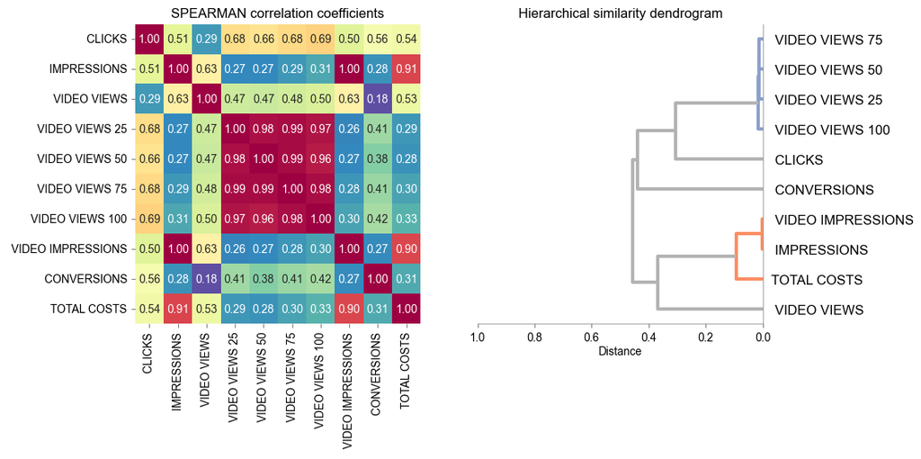

```python
### Plot Correlation matrix and Dendrogram to visualise intervariable relations

numerics = raw_df[raw_df.columns[(raw_df.dtypes == pd.Int64Dtype()) | (raw_df.dtypes == float)]]

# Process the label names into a human readable format: i64_total_clicks --> l_clicks --> clicks --> Clicks
xtick_labels = [' '.join(' '.join(i.split('i64_tota')).split('_'))[2:].upper() for i in numerics.columns]

# Using Spearman's (to be explained)
corr_plot(raw_df, xtick_labels, method="spearman")
```

```
Pearson's: 0.22, Spearman's: 0.91
```

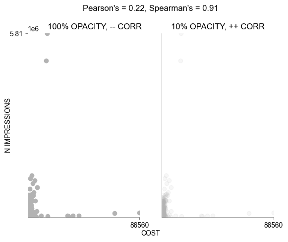

```python
### Visualise correlation between Costs and Impressions

fig = plt.figure()

s1 = raw_df['f_total_costs']
s2 = raw_df['i64_total_impressions']

# Base for subplot-non-specific labels
ax = fig.add_subplot(111)
ax1 = fig.add_subplot(121)
ax2 = fig.add_subplot(122)

ax.spines[['left', 'bottom']].set_visible(False)
ax.tick_params(labelcolor='w', top=False, bottom=False, left=False, right=False)

ax1.scatter(s1, s2)
ax1.set_title("100% opacity, -- corr".upper(), x=0.6)
ax1.set_yticks([s2.max()])
ax2.set_yticks([])
ax1.set_xticks([s1.max()])
ax2.set_xticks([s1.max()])
ax2.scatter(s1, s2, alpha=0.1)
ax2.set_title("10% opacity, ++ corr".upper())
ax.set_xlabel("Cost".upper())
ax.set_ylabel("N impressions".upper())

pr = stats.pearsonr(s1, s2)[0]
sr = stats.spearmanr(s1, s2)[0]
print(f"Pearson's: {pr:.2f}, Spearman's: {sr:.2f}")

ax.set_title(f"Pearson's = {pr:.2f}, Spearman's = {sr:.2f}", y=1.1)
plt.show()
```

- Pearson's (linear) correlation is skewed by influential outliers, when there is a clear correlation. Hence we're using Spearman's (rank) correlation
- Confirms `Cost / 1000_Impressions` as a potential metric, although Impressions must not be zero which it is for 118 values
- We shouldn't delete datapoints, but we should roughly check that these 0 values belong to the same distribution

```python
### Check statistics after zero values have been removed (optional)

table_summary(query_df("select * from `mengus.w.d` where i64_total_impressions != 0")).transpose()[['f_total_costs', 'i64_total_impressions']].style.background_gradient(axis=1).format('{:.0f}')
```

|  | f_total_costs | i64_total_impressions |
| --- | --- | --- |
| n unique values | 4147 | 5384 |
| n zeros | 392 | 0 |
| median | 3 | 927 |
| mean | 87 | 12998 |
| max | 86560 | 5809194 |

- The descriptive values shift slightly in the positive direction, which is to be expected when 0 values are deleted
- Keep these 0 values with the new metric being `Cost / (1000_Impressions + 1)`

```python
### Get all unique encrypted IDs in dataset

sep = ' \n'
s_columns = [j for j in raw_df.columns if j[0] == 's']

# Generating subqueries for distinct values in 's' columns.
query = (
    f"(select distinct s_agency as unique_ids from `mengus.w.d`) \n"
    f"{sep.join([f'union all (select distinct {i} from `mengus.w.d`)' for i in s_columns[1:]])}"
)

# Sampling distinct IDs randomly, with seed 1
ids = query_df(query).sample(frac=1, random_state=1)
total = len(ids)
print("QUERY=\t ", query)
```

```
QUERY=	  (select distinct s_agency as unique_ids from `mengus.w.d`)
union all (select distinct s_account_id from `mengus.w.d`)
union all (select distinct s_platform from `mengus.w.d`)
union all (select distinct s_network from `mengus.w.d`)
union all (select distinct s_campaign from `mengus.w.d`)
union all (select distinct s_source from `mengus.w.d`)
union all (select distinct s_medium from `mengus.w.d`)
union all (select distinct s_content from `mengus.w.d`)
union all (select distinct s_url_location from `mengus.w.d`)
```

```python
### Process encrypted IDs to replace with English words

ids['words'] = os.popen(f"sed -n '/^[a-z]*$/p' /usr/share/dict/words | sort | uniq -u | head -{total}").read().split()

# Doing this step in pd as too much boilerplate and run duration with bq
df = raw_df.copy()
id_word_map = dict(zip(ids['unique_ids'], ids['words']))

# Replace the ID with corresponding word in map
for col in s_columns:
    df[col] = df[col].map(id_word_map)

# p stands for processed
upload_df(df, 'mengus.w.p')
```

```
Loaded 11129 rows.
```

```python
### Find Cost per 1000 Impressions for each agency

agencies = query_df("""
    select
        s_agency,
        count(*) as n_records,
        avg((f_total_costs) * 1000 / (i64_total_impressions + 1)) as imp_cost_1000,
        avg((i64_total_video_views)) as view_avg
    from
        `mengus.w.p`
    group by
        1
    order by
        2 desc
""")

agencies.style.background_gradient(axis=0)
```

|  | s_agency | n_records | imp_cost_1000 | view_avg |
| --- | --- | --- | --- | --- |
| 0 | altercations | 8370 | 6.706087 | 908.175269 |
| 1 | angora | 1610 | 2.493213 | 5070.230435 |
| 2 | apostates | 687 | 3.026145 | 4710.518195 |
| 3 | aches | 387 | 6.131494 | 15625.372093 |
| 4 | baleen | 73 | 505.522239 | 3685.109589 |
| 5 | amour | 2 | 15.275344 | 26377.500000 |

- We probably cannot trust the values of `baleen` and `amour`, as there are too few records
- There is great variability and little concordance with the more reliable `imp_cost_1000` metric regarding `view_avg`
- `imp_cost_1000` is the main metric I will use to compare the agencies

```python
### Get Cost per 1000 Impressions series for each agency

sep = " \n\t"
query = (f"""
    select
        {sep.join([f"(case when s_agency = '{a}' then (f_total_costs * 1000 / (i64_total_impressions + 1)) else null end) as {a}," for a in agencies['s_agency']])}
    from `mengus.w.p`""")

# cpi = cost per impressions
cpi = query_df(query)
print(query)
```

```
    select
        (case when s_agency = 'altercations' then (f_total_costs * 1000 / (i64_total_impressions + 1)) else null end) as altercations,
	(case when s_agency = 'angora' then (f_total_costs * 1000 / (i64_total_impressions + 1)) else null end) as angora,
	(case when s_agency = 'apostates' then (f_total_costs * 1000 / (i64_total_impressions + 1)) else null end) as apostates,
	(case when s_agency = 'aches' then (f_total_costs * 1000 / (i64_total_impressions + 1)) else null end) as aches,
	(case when s_agency = 'baleen' then (f_total_costs * 1000 / (i64_total_impressions + 1)) else null end) as baleen,
	(case when s_agency = 'amour' then (f_total_costs * 1000 / (i64_total_impressions + 1)) else null end) as amour,
    from `mengus.w.p`
```

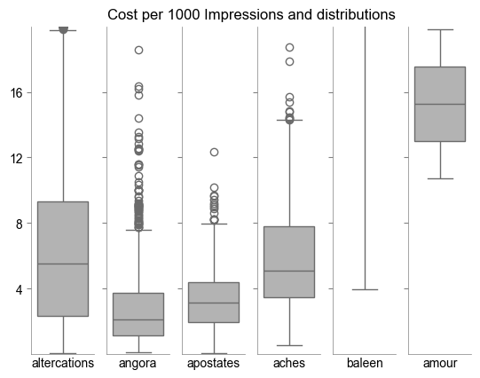

```python
### Distribution boxplots for each agency

fig, ax = plt.subplots(1, 6, sharey=True)
base = fig.add_subplot(111)
plt.subplots_adjust(hspace=0.4)
for i in range(6):
    agency = cpi.columns[i]
    s = cpi[agency]
    s = s[s > 0]
    sns.boxplot(s, ax=ax[i])
    ax[i].set_ylim(0, 20)
    ax[i].set_xticks([])
    ax[i].set_xlabel(agency)
    ax[i].set_yticks([i for i in range(4, 20, 4)])
    ax[i].set_ylabel("")
base.set_title("Cost per 1000 Impressions and distributions")
base.axis("off")
plt.show()
```

- `angora` is looking like the most cost effective marketing agency when looking at outreach
- Assuming these series are samples from an underlying distribution, it is worthwhile checking if the medians are statistically different from each other

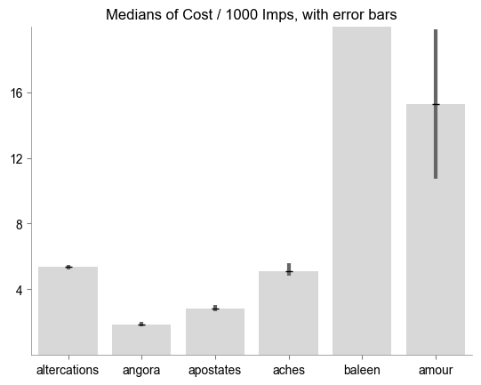

```python
### Plot medians with error bars for each agency

medians = []
errors = []
for col in cpi:

    # Select non-null values from the column. ',' to make it a tuple
    s = cpi[col]
    s = s[s.notna()],

    # Compute confidence interval for median using bootstrap resampling
    l, u = stats.bootstrap(s, lambda s: np.median(s)).confidence_interval
    medians.append(s[0].median())
    errors.append((l, u))

preerr = np.array(errors).T.tolist()
meds = np.array([medians]).repeat(2, axis=0)
err = np.abs(preerr - meds)

plt.bar(cpi.columns, medians, alpha=0.5)
plt.errorbar(np.arange(6), medians, yerr=err, fmt='_', zorder=100, lw=3, gapcolor='k', mec='k', color='0.4')
plt.ylim(0, 20)
plt.xlim(-0.5, 5.5)
plt.yticks([i for i in range(4, 20, 4)])
plt.title("Medians of Cost / 1000 Imps, with error bars")
plt.show()
```

# Selection: ANGORA